# Eighth Week: Text Analysis in R

To be, or not to be

Aida Ramezani 95105595

2018-05-05 02:07:46

[interactive chart not shown]

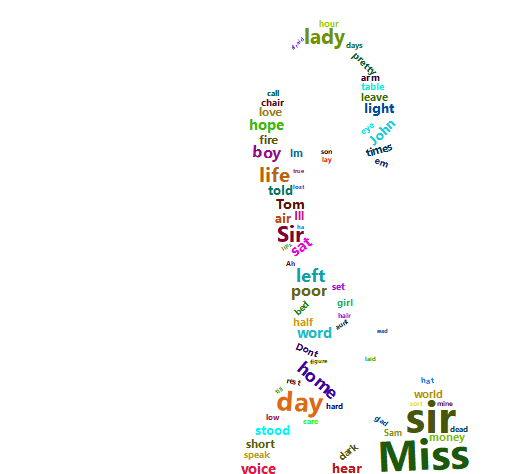

[interactive chart not shown]

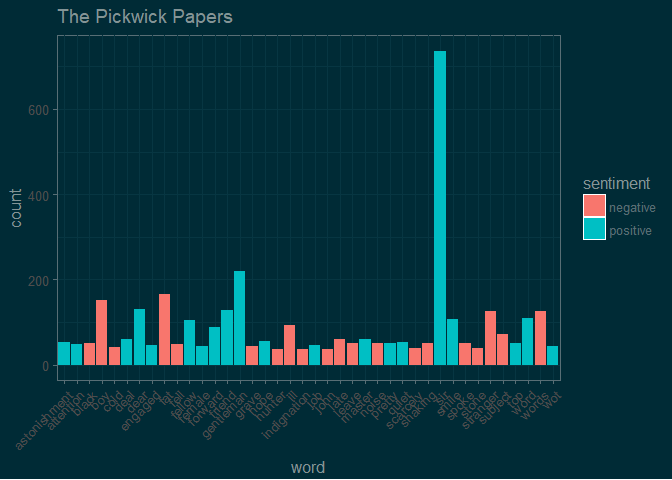

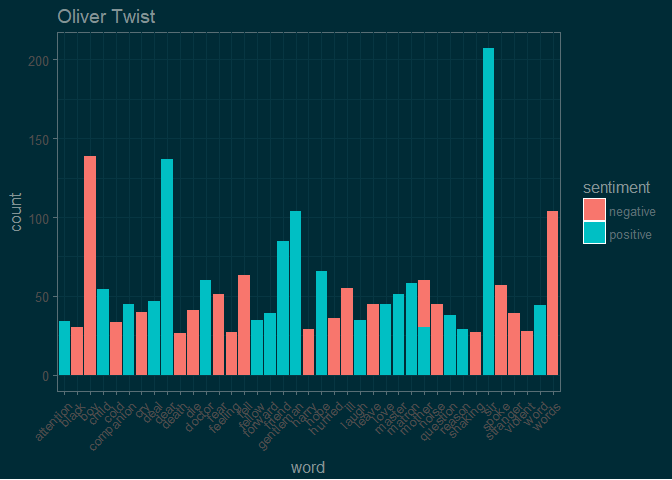

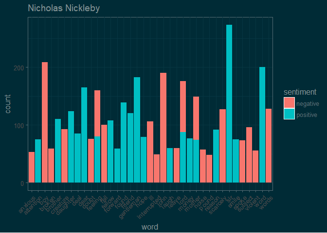

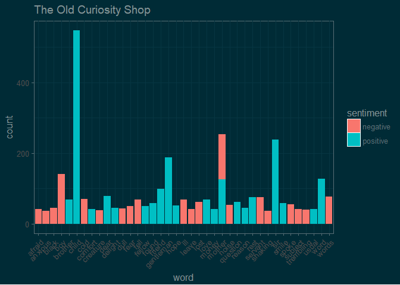

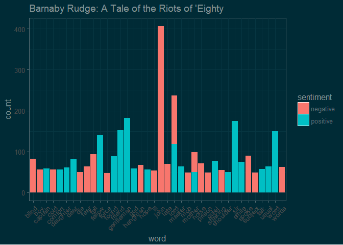

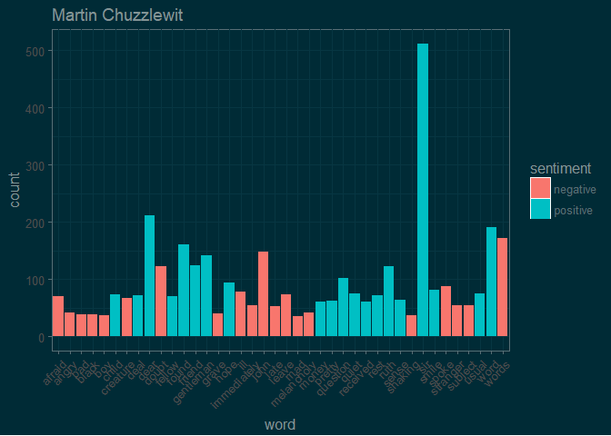

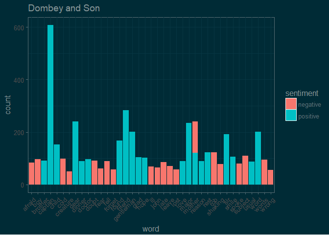

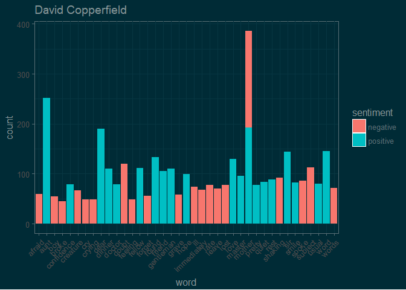

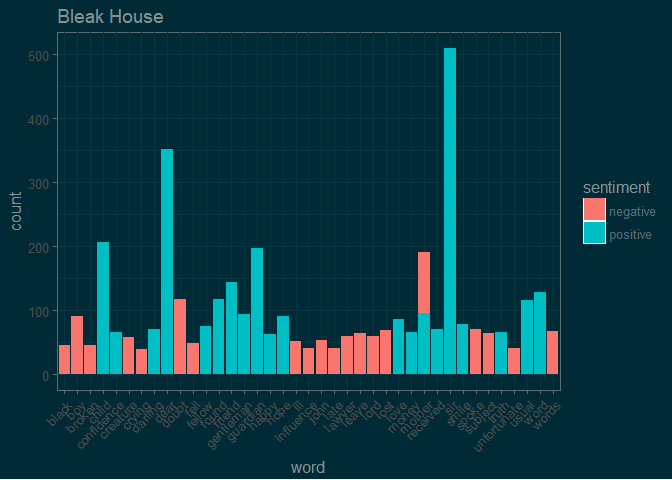

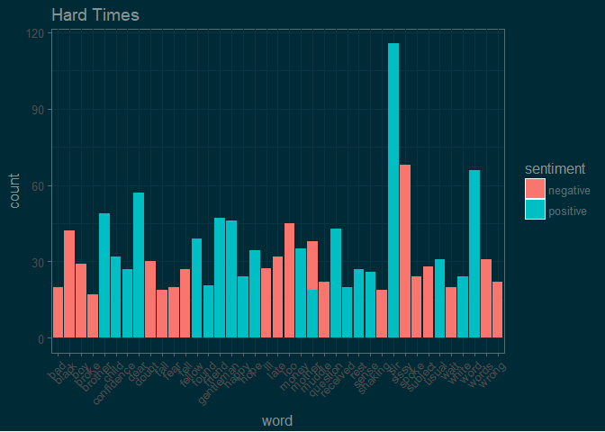

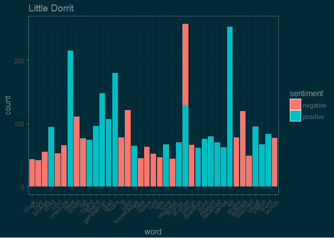

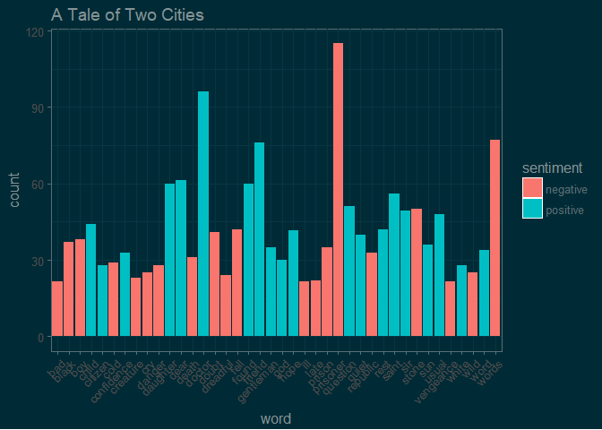

[2 more figures not shown]

5. با توجه به نمودار به دست آمده، داستان در فصول میانی دارای فضایی ناراحت کننده بوده ولی در فصل آخر فضای داستان به سمت مثبت بودن میرود.

[interactive chart not shown]

ابتدا فصل های هر کتاب جداسازی شده اند و سپس به ازای هر فصل 1-gram و 2-gram آن پیدا شده اند و توزیع کلمات محاسبه شده اند. برای نمونه نیز 6 نمودار از فصل های مختلف کتاب های مختلف رسم شده اند.

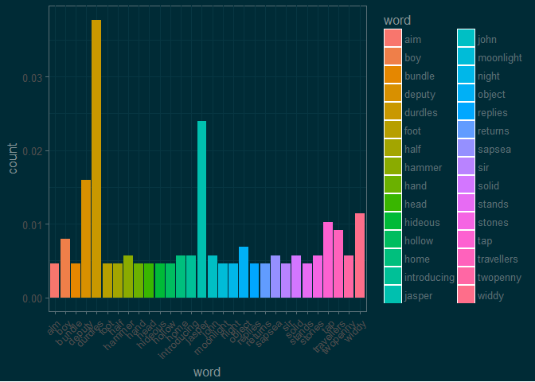

```r
roman_numbers <- unlist(as.character(as.roman(1:200)))
bind_rows(Dbooks) -> dickens_books_lines

dickens_books_lines %>% group_by(gutenberg_id) %>%
  filter(row_number() >= 100) -> dickens_books_no_content


original_books <- dickens_books_no_content %>%
  group_by(gutenberg_id) %>%
  mutate(linenumber = row_number(),
         chapter = cumsum(str_detect(text, regex("^chapter [\\divxlc]",ignore_case = TRUE)) )) %>%
  ungroup() %>% filter(chapter > 0)



dickens_unigram <- original_books %>%
  unnest_tokens(word, text) %>% filter(!word %in% stop_words$word)


dickens_bigram <- original_books %>%  unnest_tokens(bigram, text, token = "ngrams", n = 2)
bigrams_separated <- dickens_bigram %>%  separate(bigram, c("word1", "word2"), sep = " ")
bigrams_separated %>%  filter(!(word1 %in% stop_words$word)) %>%  filter(!(word2 %in% stop_words$word)) -> bigrams_separated
bigrams_united <- bigrams_separated %>%  unite(bigram, word1, word2, sep = " ")

dickens_unigram %>% group_by(chapter, gutenberg_id) %>%
  mutate(numberOfwords = n()) -> dickens_unigram

dickens_unigram %>% filter(word != "NA") %>% group_by(gutenberg_id, chapter, word) %>%
  summarise(count = n() / mean(numberOfwords)) %>% mutate(rank = rank(-count , ties.method = "first"))-> unigram_distribution

bigrams_united %>% filter(bigram != "NA NA") %>% group_by(chapter, gutenberg_id) %>%
  mutate(numberOfwords = n()) -> bigrams_united

bigrams_united %>% group_by(gutenberg_id, chapter, bigram) %>%
  summarise(count = n() / mean(numberOfwords)) %>% mutate(rank = rank(-count , ties.method = "first")) -> bigram_distribution


unigram_distribution %>% filter(gutenberg_id == 564 , chapter == 4) %>% arrange(desc(count)) %>% head(30) %>%
  ggplot(aes(x = word , y = count)) + geom_bar(stat = "identity", aes(fill = word)) +  theme_solarized(light = FALSE) +
  scale_colour_solarized("red") +
  theme(axis.text.x = element_text(
    angle = 45,
    vjust = 1,
    hjust = 1
  ))
```

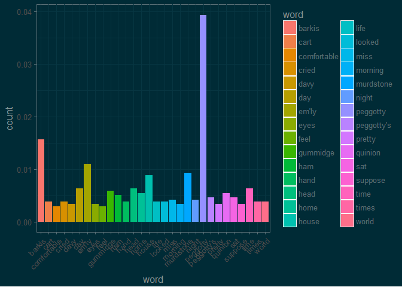

```r
unigram_distribution %>% filter(gutenberg_id == 766 , chapter == 10)%>% arrange(desc(count)) %>% head(30) %>%
  ggplot(aes(x = word , y = count)) + geom_bar(stat = "identity", aes(fill = word)) +  theme_solarized(light = FALSE) +
  scale_colour_solarized("red") +
  theme(axis.text.x = element_text(
    angle = 45,
    vjust = 1,
    hjust = 1
  ))
```

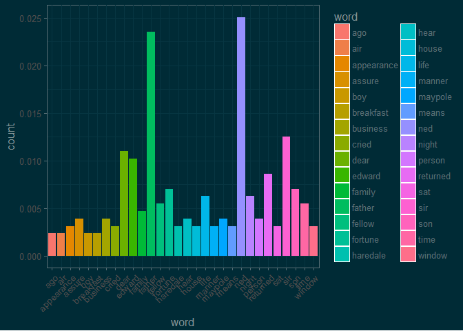

```r
unigram_distribution %>% filter(gutenberg_id == 917 , chapter == 15)%>% arrange(desc(count)) %>% head(30) %>%
  ggplot(aes(x = word , y = count)) + geom_bar(stat = "identity", aes(fill = word)) +  theme_solarized(light = FALSE) +
  scale_colour_solarized("red") +
  theme(axis.text.x = element_text(
    angle = 45,
    vjust = 1,
    hjust = 1
  ))
```

```r
bigram_distribution %>% filter(gutenberg_id == 564 , chapter == 4)%>% arrange(desc(count)) %>% head(30) %>%
  hchart(hcaes(x = bigram, y = count), type = "column")%>%
  hc_add_theme(hc_theme_sandsignika())
```

[interactive chart not shown]

```r
bigram_distribution %>% filter(gutenberg_id == 766 , chapter == 10)%>% arrange(desc(count)) %>% head(30) %>%
  hchart(hcaes(x = bigram, y = count), type = "column")%>%
  hc_add_theme(hc_theme_sandsignika())
```

[interactive chart not shown]

```r
bigram_distribution %>% filter(gutenberg_id == 917 , chapter == 15)%>% arrange(desc(count)) %>% head(30) %>%
  hchart(hcaes(x = bigram, y = count), type = "column")%>%
  hc_add_theme(hc_theme_sandsignika())
```

[interactive chart not shown]

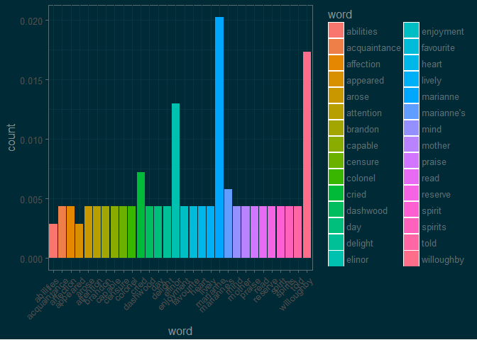

```r
library(janeaustenr)
original_books <- austen_books() %>%  group_by(book) %>%
  mutate(linenumber = row_number(),
         chapter = cumsum(str_detect(text, regex("^chapter [\\divxlc]",ignore_case = TRUE)))) %>%  ungroup()



austin_unigram <- original_books %>%
  unnest_tokens(word, text) %>% filter(!word %in% stop_words$word)


austin_bigram <- original_books %>%  unnest_tokens(bigram, text, token = "ngrams", n = 2)
bigrams_separated <- austin_bigram %>%  separate(bigram, c("word1", "word2"), sep = " ")
bigrams_separated %>%  filter(!(word1 %in% stop_words$word)) %>%  filter(!(word2 %in% stop_words$word)) -> bigrams_separated

bigrams_united <- bigrams_separated %>%  unite(bigram, word1, word2, sep = " ")


austin_unigram %>% group_by(chapter, book) %>%
  mutate(numberOfwords = n()) -> austin_unigram

austin_unigram %>% filter(word != "NA") %>% group_by(book, chapter, word) %>%
  summarise(count = n() / mean(numberOfwords)) %>% mutate(rank = rank(-count , ties.method = "first"))-> unigram_distribution

bigrams_united %>% filter(bigram != "NA NA") %>% group_by(chapter, book) %>%
  mutate(numberOfwords = n()) -> bigrams_united

bigrams_united %>% group_by(book, chapter, bigram) %>%
  summarise(count = n() / mean(numberOfwords)) %>% mutate(rank = rank(-count , ties.method = "first")) -> bigram_distribution

unigram_distribution %>% filter(book == "Sense & Sensibility", chapter == 10) %>% arrange(desc(count)) %>% head(30) %>%
  ggplot(aes(x = word , y = count)) + geom_bar(stat = "identity", aes(fill = word))+  theme_solarized(light = FALSE) +
  scale_colour_solarized("red") +
  theme(axis.text.x = element_text(
    angle = 45,
    vjust = 1,
    hjust = 1
  ))
```

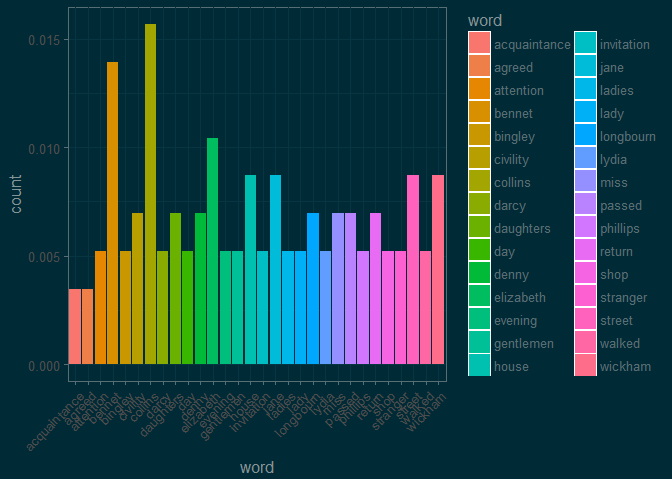

```r
unigram_distribution %>% filter(book == "Pride & Prejudice", chapter == 15) %>% arrange(desc(count)) %>% head(30) %>%
  ggplot(aes(x = word , y = count)) + geom_bar(stat = "identity", aes(fill = word))+  theme_solarized(light = FALSE) +
  scale_colour_solarized("red") +
  theme(axis.text.x = element_text(
    angle = 45,
    vjust = 1,
    hjust = 1
  ))
```

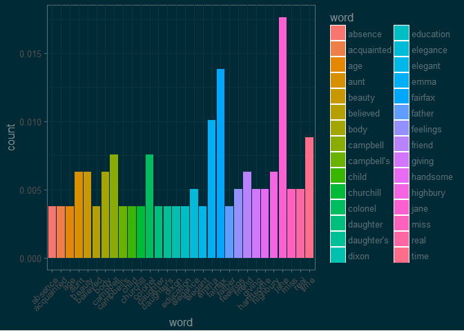

```r
unigram_distribution %>% filter(book == "Emma", chapter == 20) %>% arrange(desc(count)) %>% head(30) %>%
  ggplot(aes(x = word , y = count)) + geom_bar(stat = "identity", aes(fill = word))+  theme_solarized(light = FALSE) +
  scale_colour_solarized("red") +
  theme(axis.text.x = element_text(
    angle = 45,
    vjust = 1,
    hjust = 1
  ))
```

```r
bigram_distribution %>% filter(book == "Sense & Sensibility", chapter == 10) %>% arrange(desc(count)) %>% head(30) %>%
  hchart(hcaes(x = bigram,  y = count) , type = "column") %>%
  hc_add_theme(hc_theme_sandsignika())
```

[interactive chart not shown]

```r
bigram_distribution %>% filter(book == "Pride & Prejudice", chapter == 3) %>% arrange(desc(count)) %>% head(30) %>%
  hchart(hcaes(x = bigram,  y = count) , type = "column") %>%
  hc_add_theme(hc_theme_sandsignika())
```

[interactive chart not shown]

```r
bigram_distribution %>% filter(book == "Emma", chapter == 20) %>% arrange(desc(count)) %>% head(30) %>%
  hchart(hcaes(x = bigram,  y = count) , type = "column") %>%
  hc_add_theme(hc_theme_sandsignika())
```

[interactive chart not shown]

کلمات مهم کتاب های دو نویسنده چارلز دیکنز و جین آستین و توزیع آن ها برای هر فصل محاسبه شده اند و به عنوان داده train به مدل logestic میدهیم. داده تست را بر روی کتاب های Oliver Twist و Pride & Prejudice میسازیم و به مدل میدهیم. سپس خطای مدل را حساب میکنیم. برای این محسابه 2 gram در نظر گرفته شده است.

[output not shown]

```
## Model Details:
## ==============
##
## H2OBinomialModel: glm
## Model ID:  GLM_model_R_1525464864529_11
## GLM Model: summary
##     family  link                               regularization
## 1 binomial logit Elastic Net (alpha = 0.5, lambda = 0.02923 )
##   number_of_predictors_total number_of_active_predictors
## 1                         59                          38
##   number_of_iterations training_frame
## 1                    4          train
##
## Coefficients: glm coefficients
##               names coefficients standardized_coefficients
## 1         Intercept     1.568642                  1.276212
## 2   captain benwick    -5.038640                 -0.017437
## 3 captain wentworth   -37.785383                 -0.296630
## 4   colonel brandon   -62.839693                 -0.436132
## 5         dear miss   -60.579455                 -0.121476
##
## ---
##               names coefficients standardized_coefficients
## 55      replied sam     0.000000                  0.000000
## 56 single gentleman     0.000000                  0.000000
## 57    sir leicester     4.637443                  0.042929
## 58     sir mulberry     0.000000                  0.000000
## 59      sir replied   119.206462                  0.353661
## 60     sir returned    89.848501                  0.297826
##
## H2OBinomialMetrics: glm
## ** Reported on training data. **
##
## MSE:  0.03640536
## RMSE:  0.1908019
## LogLoss:  0.1603643
## Mean Per-Class Error:  0.004926108
## AUC:  0.9995642
## Gini:  0.9991285
## R^2:  0.8197221
```

[output cut: 8 more lines]

```
##
## Maximum Metrics: Maximum metrics at their respective thresholds
##                         metric threshold    value idx
## 1                       max f1  0.827590 0.998081 232
## 2                       max f2  0.827590 0.999231 232
## 3                 max f0point5  0.827590 0.996933 232
## 4                 max accuracy  0.827590 0.997234 232
## 5                max precision  0.998964 1.000000   0
## 6                   max recall  0.827590 1.000000 232
## 7              max specificity  0.998964 1.000000   0
## 8             max absolute_mcc  0.827590 0.993154 232
## 9   max min_per_class_accuracy  0.827590 0.990148 232
## 10 max mean_per_class_accuracy  0.827590 0.995074 232
##
## Gains/Lift Table: Extract with `h2o.gainsLift(<model>, <data>)` or `h2o.gainsLift(<model>, valid=<T/F>, xval=<T/F>)`
```

```
## [1] 24.44444
```

همچنین در زیر با استفاده از آزمون خیدو میزان شباهت آثار این دو نویسنده بر حسب 2 gram محاسبه شده است:

```
##
##  Pearson's Chi-squared test
##
## data:  bigram_distribution %>% select(count)
## X-squared = 2873600, df = 441490, p-value < 2.2e-16
```